# English Premier League (EPL) Match Predictor

Omotoyosi Taiwo

2/06/2020

# Introduction

Football Matches are notoriously hard to predict due to the random and low scoring nature of the games. One of the obvious prevailing wisdom however, is that Home teams win more on average, and this has been [statistically proven](https://bleacherreport.com/articles/1604854-how-much-does-home-field-advantage-matter-in-soccer). In recent years, more advanced metrics have been proposed to account for variance in styles and team performances in outcome and goals prediction. An example is xG (Expected Goals) this calculates the possible goals teams should have scored based on shot location, however even that does not account for factors like defence engagement, the time the shot was attempted, and the current scoreline all which hypothetically affect players.

These factors and many have made soccer really difficult to predict. Betting companies develop advanced algortithms to generate true odds for football matches even though they adjust these odds so that they always turn a profit.

The idea behind this project is to use the closing betting data, team form (using rolling averages of n previous games for various stats) and 538 metrics including expected goals, team reputation (SPI), and projected scores to improve prediction.

The data I used for this project was downloaded from [football-data.co.uk](http://www.football-data.co.uk/englandm.php)and [fivethirtyeight.](https://projects.fivethirtyeight.com/soccer-predictions/)

Because 538 metrics only go back to the beginning of the 16/17 season, this limits the observations in the dataset which will most probably reduce accuracy. I will keep looking out for updates for previous seasons once it becomes availabe and use it to improve model

> Future work

Create a data pipeline that automatically scrapes betting data and spi data once it becomes available and uses it to improve prediction

# Preparing the Data

I will be using mostly R data.table, because I love how blazing fast data.tables are and it’s one-liner approach to data manipulation

```r
# Read Match Stats and Betting data
EPL1819_all = fread("season-1819_csv.csv")
EPL1718_all = fread("season-1718_csv.csv")
EPL1617_all = fread("season-1617_csv.csv")
EPL1920_all = fread("season-1920_csv.csv")
setnames(EPL1920_all,c("AvgA","AvgH","AvgD"), c("BbAvA","BbAvH","BbAvD"))#Fix closing betting averages name changes from the 19/20 dataset

# Seperate Modelling Data that doesn't need to be aggregated
modelCols = c("HomeTeam","AwayTeam","FTR","BbAvH","BbAvD","BbAvA")
EPL1617_mod = EPL1617_all[,..modelCols]
EPL1718_mod = EPL1718_all[,..modelCols]
EPL1819_mod = EPL1819_all[,..modelCols]
EPL1920_mod = EPL1920_all[,..modelCols]
modelData = rbind(EPL1617_mod, EPL1718_mod,EPL1819_mod ,EPL1920_mod)

# Remove Extraneous columns
relevantColumns = c("HomeTeam","AwayTeam","FTHG","FTAG","HTHG","HTAG","HS","AS","HST","AST","HF","AF","HC","AC","HY","AY","HR","AR")
EPL1617 = EPL1617_all[,..relevantColumns]
EPL1718 = EPL1718_all[,..relevantColumns]
EPL1819 = EPL1819_all[,..relevantColumns]
EPL1920 = EPL1920_all[,..relevantColumns]

# Load 538 spi ratings and xG data
spiMatches = fread("spi_matches.csv")
spiMatches = spiMatches[league == "Barclays Premier League",]

# Format spi data to fit stats and betting data - Different team names in both data set
setnames(spiMatches,c("team1","team2"), c("HomeTeam","AwayTeam"))

spiTeamToChange = c("Hull City", "Manchester City", "AFC Bournemouth","Manchester United", "Leicester City", "Stoke City", "Swansea City", "Tottenham Hotspur","West Bromwich Albion","West Ham United", "Brighton and Hove Albion", "Huddersfield", "Wolverhampton", "Cardiff City", "Norwich City")

changeTo = c("Hull","Man City","Bournemouth", "Man United", "Leicester", "Stoke", "Swansea", "Tottenham","West Brom","West Ham","Brighton","Huddersfield","Wolves", "Cardiff", "Norwich")

# Change team names to match
for(i in 1:length(spiTeamToChange)) {
  spiMatches[HomeTeam== spiTeamToChange[i],HomeTeam:=changeTo[i]]
  spiMatches[AwayTeam== spiTeamToChange[i],AwayTeam:=changeTo[i]]
}

# Sort to match order - Betting data is sorted by date, then home team name.
spiMatches[,date := as.Date(date,format="%Y-%m-%d")]
setorder(spiMatches, date, HomeTeam)
```

I decided to use an attacking variable based on the aggregation of 3 goal variables provided by 538. xg is the number of goals each team was expected to score, nsxg is the non shot expected goals, and adj_score is the ajusted score 538 gave each team to account for expected efficiency of goal conversion as many things being equal.

I also included a new variable to account for how badly teams perform relative to their attacking value, this feature was called Inefficiency I decided to subtract the full time goals each team scored from he attacking number and this represents how Inefficient teams are (Another approach would be to use the ratio)

```r
#Generate agg cols for spi
spiMatches[, attack1 := xg1 +nsxg1 +adj_score1]
spiMatches[, attack2 := xg2 +nsxg2 +adj_score2]

#Column bind spi data and betting data. There are 380 matches every season
EPL1617 = cbind(EPL1617, spiMatches[1:380,17:24])
EPL1718 = cbind(EPL1718, spiMatches[381:760,17:24])
EPL1819 = cbind(EPL1819, spiMatches[761:1140,17:24])
EPL1920 = cbind(EPL1920, spiMatches[1141:(1140+nrow(EPL1920)),17:24])

#Efficiency
EPL1617[,`:=` (Inefficiency1 = attack1 - FTHG, Inefficiency2 = attack2 - FTAG)]
EPL1718[,`:=` (Inefficiency1 = attack1 - FTHG, Inefficiency2 = attack2 - FTAG)]
EPL1819[,`:=` (Inefficiency1 = attack1 - FTHG, Inefficiency2 = attack2 - FTAG)]
EPL1920[,`:=` (Inefficiency1 = attack1 - FTHG, Inefficiency2 = attack2 - FTAG)]

allSeasons = list(EPL1617,EPL1718,EPL1819,EPL1920)

#List to hold all tables that have the new columns
meltedDataList = list()

#Separate Predictor variables from Aggregators.
aggregateEplCols = c("HomeTeam","AwayTeam","FTHG","FTAG","HTHG","HTAG","HS","AS","HST","AST","HF","AF","HC","AC","HY","AY","HR","AR")

seasonMeltMeasureList = list(c("HomeTeam", "AwayTeam"), c("FTHG", "FTAG"), c("HTHG", "HTAG"), c("HS", "AS"), c("HST", "AST"), c("HF", "AF"), c("HC", "AC"),
                             c("HY", "AY"), c("HR", "AR"), c("xg1", "xg2"), c("nsxg1", "nsxg2"), c("adj_score1", "adj_score2"), c("attack1", "attack2"), c("Inefficiency1","Inefficiency2"))

seasonMeltNames = c("Team","FTG","HTG","Shots","ST","Fouls","Corners","Yellow","Red","xg","nsxg","adj_score","attack","Inefficiency")

#For loop to aggregate each season data
for(season in allSeasons){
  #Melt to combine home and away results - Note separate running averages in future
  season = melt(season, measure = seasonMeltMeasureList, value.name = seasonMeltNames)
  meltedDataList[[length(meltedDataList)+1]] <- season
}
allMeltedData = rbindlist(meltedDataList)

#New columns for the rolling Averages
rollingAvgColumns = paste0(c("FTG","HTG","Shots","ST","Fouls","Corners","Yellow","Red","xg","nsxg","adj_score","attack","Inefficiency"),"rAvg")

##Custom function - Find the rolling mean and then shift by 1, so that the previous averages are used
shift_froll = function(x, n){shift(frollmean(x, n= n))}
#bMelted[,variable:= as.factor(variable)]

#Rolling Maean and Shift
allMeltedData[, (rollingAvgColumns):= lapply(.SD, shift_froll,  n = 5), by = c("Team","variable"), .SDcols =  c("FTG","HTG","Shots","ST","Fouls","Corners","Yellow","Red","xg","nsxg","adj_score","attack","Inefficiency")]

#Fill NA values from rolling window and shifting with mean
allMeltedData[,16:28 := na.aggregate(allMeltedData[,16:28] )]

#Modelling Data
#--------------
#Fold data into Home and Away
awayNames = names(allMeltedData[,16:28])#Get table names except variable
awayNames = paste0(awayNames,"Away")#Add away to specify stats
allHome = allMeltedData[variable == 1, 16:28] #Home Stats without variable
allAway = allMeltedData[variable == 2, 16:28] #Away stats without the variable
names(allAway) = awayNames
allBound = cbind(allHome, allAway)

#Column bind data to get home and away wide table
finalData = cbind(modelData, allBound,spiMatches[1:nrow(allBound),6:12])
```

# Generate Modelling Data

After the data has been reshaped to calculate team forms by doing rolling avergaes, as this is a head to head, I decided to subtract the away team statistics from the home team statistics to show the relative difference between the teams. [In the future look into other correlations between the variables, either using ratios or using the values as is ]

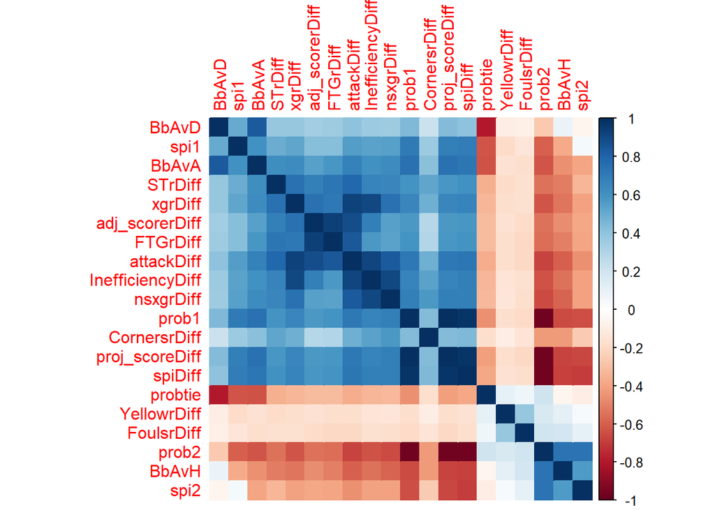

```r
#Tree Model
ModelData = finalData[101:nrow(finalData),3:ncol(finalData)]

#Find difference in stats by team
ModelData[,`:=` (FTGrDiff = FTGrAvg - FTGrAvgAway, STrDiff = STrAvg - STrAvgAway, FoulsrDiff = FoulsrAvg - FoulsrAvgAway,
                 CornersrDiff = CornersrAvg - CornersrAvgAway, YellowrDiff = YellowrAvg - YellowrAvgAway, xgrDiff = xgrAvg - xgrAvgAway,
                 nsxgrDiff = nsxgrAvg - nsxgrAvgAway, adj_scorerDiff = adj_scorerAvg - adj_scorerAvgAway, spiDiff = spi1 - spi2,
                 proj_scoreDiff = proj_score1 - proj_score2, attackDiff = attackrAvg - attackrAvgAway,
                 InefficiencyDiff = InefficiencyrAvg - InefficiencyrAvgAway)]

#Remove unneeded cols
ModelData[,5:30:=NULL]
toRemove = c("proj_score1","proj_score2")
ModelData[,(toRemove):=NULL]

#Variable Analysis
corrplot(cor(ModelData[,2:ncol(ModelData)]), method ="color",order = "AOE")
```

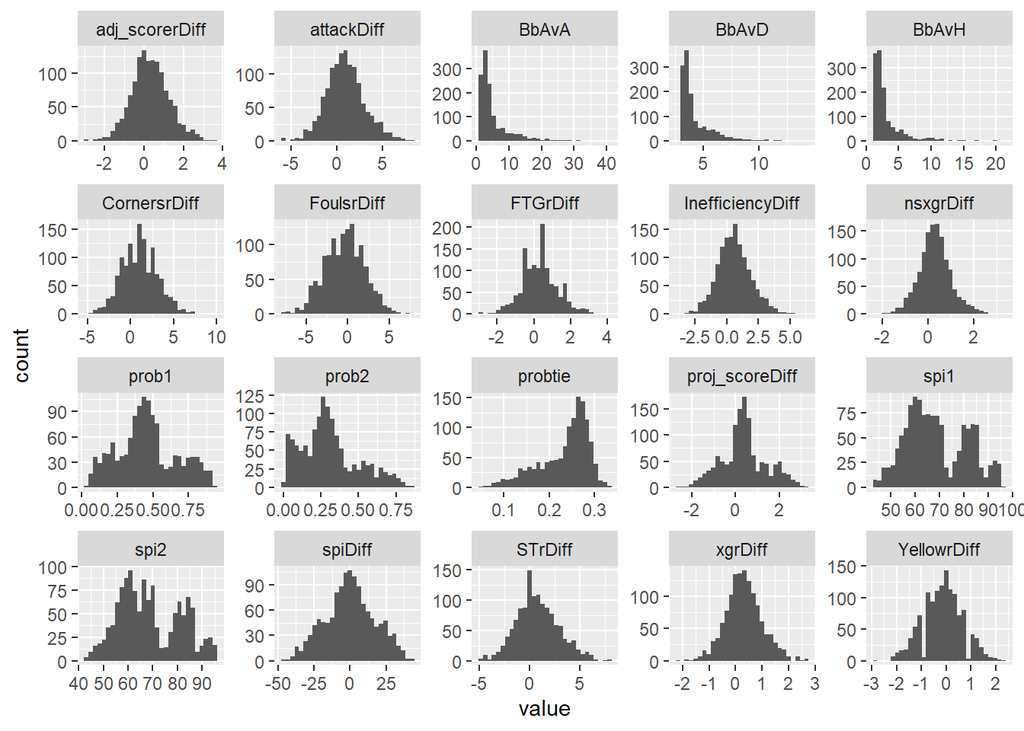

```r
ModelData[,2:ncol(ModelData)]%>%gather()%>%ggplot(aes(value))+facet_wrap(~key, scales = "free")+geom_histogram()
```

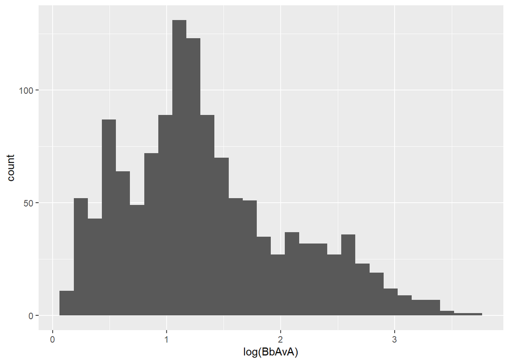

```r
ggplot(ModelData[,2:ncol(ModelData)],aes(log(BbAvA)))+geom_histogram()
```

```r
#transformedModelData
ModelData[,`:=` (BbAvA=log(BbAvA), BbAvD=log(BbAvD), BbAvH=log(BbAvH), FTR= as.factor(FTR))]
```

#Principal Component Analysis

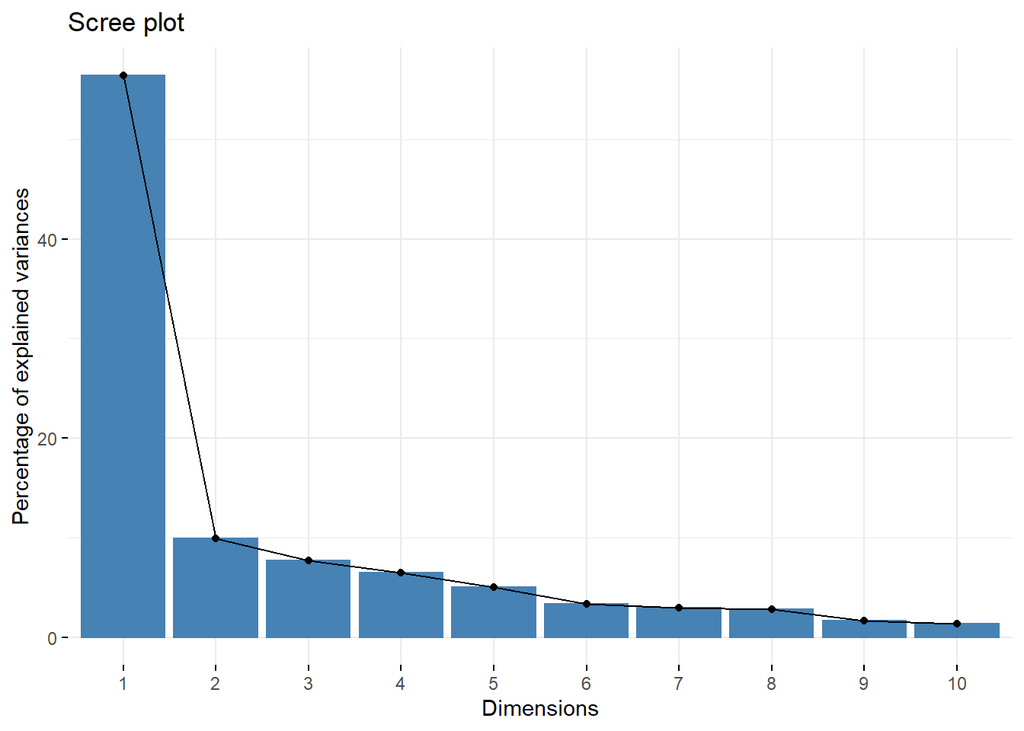

```r
pcaEPL = prcomp(ModelData[,-1], scale=T)
fviz_eig(pcaEPL)
```

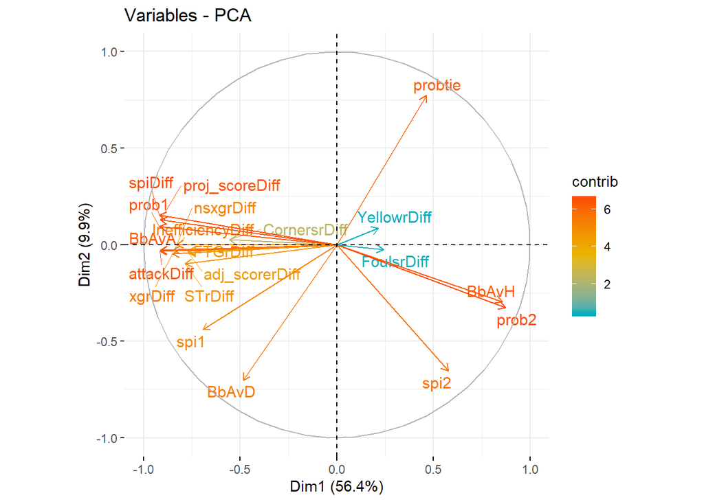

```r
#Variables
fviz_pca_var(pcaEPL,
             col.var = "contrib", # Color by contributions to the PC
             gradient.cols = c("#00AFBB", "#E7B800", "#FC4E07"),
             repel = TRUE     # Avoid text overlapping
             )
```

```r
#PCA result
eplVariablesPCA = get_pca_var(pcaEPL)
eplVariablesPCA$coord
```

```
##                       Dim.1        Dim.2      Dim.3        Dim.4       Dim.5
## BbAvH             0.8567215 -0.295147829 -0.1014172  0.018286002 -0.05814306
## BbAvD            -0.4855895 -0.701788675  0.2347118  0.046008869 -0.12790354
## BbAvA            -0.9126330 -0.029345223  0.1823449  0.002674597 -0.01924178
## spi1             -0.6939043 -0.440913338  0.2567393 -0.057739800  0.13697059
## spi2              0.5760180 -0.654123961 -0.1822404 -0.041183724  0.20428441
## prob1            -0.9169904  0.094514390  0.3526546 -0.043013184 -0.05844685
## prob2             0.8722289 -0.326555904 -0.3125719  0.052481600  0.03353778
## probtie           0.4622436  0.773212440 -0.2570910 -0.018455592  0.10591049
## FTGrDiff         -0.7705700 -0.034934974 -0.3847546  0.022289548 -0.40725126
## STrDiff          -0.7849443 -0.099922719 -0.3079519  0.058677901  0.03284695
## FoulsrDiff        0.2418479 -0.025931370  0.1442128  0.776674758 -0.03941308
## CornersrDiff     -0.5557991  0.024803909 -0.1010840  0.049185830  0.64686802
## YellowrDiff       0.2155687  0.086544457  0.1373288  0.790592954 -0.02378166
## xgrDiff          -0.8504101 -0.048118572 -0.3414099  0.101747220  0.05572940
## nsxgrDiff        -0.8285399  0.002849741 -0.1458667  0.097859928  0.33277529
## adj_scorerDiff   -0.7680856 -0.042443405 -0.4353761  0.058103564 -0.38280276
## spiDiff          -0.9191775  0.154044179  0.3177446 -0.012007757 -0.04863520
## proj_scoreDiff   -0.9122799  0.129373439  0.3418540 -0.048935845 -0.05280820
## attackDiff       -0.9162880 -0.034432097 -0.3621687  0.093773680 -0.04270790
## InefficiencyDiff -0.8469046 -0.027366924 -0.2749579  0.128854528  0.23740735
##                        Dim.6        Dim.7        Dim.8        Dim.9
## BbAvH             0.01388739 -0.066293403  0.167211994 -0.302417263
## BbAvD             0.30756982 -0.199953516  0.087636568  0.028052791
## BbAvA             0.14678259 -0.063545927 -0.091212709  0.261823607
## spi1             -0.35833900  0.281087056 -0.126102518 -0.033617943
## spi2             -0.25972927  0.249277812 -0.131645715  0.069810911
## prob1            -0.05656086  0.030696680  0.013250348 -0.091306947
## prob2             0.09640929 -0.051416539  0.003657644  0.085228013
## probtie          -0.11930243  0.061602422 -0.063007391  0.051698637
## FTGrDiff          0.01592538  0.046804498 -0.226445918 -0.043906855
## STrDiff           0.05091132 -0.083126677 -0.271621583  0.150705302
## FoulsrDiff       -0.38107701 -0.396892168 -0.099969406  0.009483731
## CornersrDiff      0.24271629 -0.129000394 -0.333197882 -0.247251974
## YellowrDiff       0.30802345  0.452365755  0.004247397 -0.010943152
## xgrDiff          -0.06109840 -0.026398068  0.174267865 -0.036837900
## nsxgrDiff        -0.01920464  0.014623508  0.255345625  0.139136025
## adj_scorerDiff   -0.02586068  0.059922811 -0.077455862 -0.141155013
## spiDiff          -0.07152668  0.023155694  0.003947576 -0.074850971
## proj_scoreDiff   -0.05985243  0.027205858  0.016999669 -0.090367452
```

[output cut: 50 more lines]

```
## prob1            -3.361584e-28 -2.180302e-28  8.647463e-29
## prob2            -3.064140e-28 -1.989108e-28  7.862780e-29
## probtie          -8.817280e-29 -5.728216e-29  2.269716e-29
## FTGrDiff         -2.506041e-16 -2.274138e-16 -1.330400e-16
## STrDiff           8.660373e-31  1.846354e-31  1.629091e-31
## FoulsrDiff        1.088074e-31  4.093810e-32  1.769664e-33
## CornersrDiff      1.351319e-31 -2.678890e-32 -1.944935e-32
## YellowrDiff       2.475812e-31 -1.636539e-32 -1.879341e-32
## xgrDiff          -3.571351e-16  1.529830e-16  8.280650e-17
## nsxgrDiff        -3.653040e-16  1.564822e-16  8.470057e-17
## adj_scorerDiff   -4.891326e-16  2.095256e-16  1.134119e-16
## spiDiff          -5.129663e-17 -3.088085e-16  2.131004e-16
## proj_scoreDiff    6.508144e-31 -1.390260e-31 -7.384138e-32
## attackDiff        1.593193e-15  1.402864e-17  2.828571e-17
## InefficiencyDiff -3.360939e-16 -3.049926e-16 -1.784246e-16
```

```r
eplVariablesPCA$contrib
```

```
##                      Dim.1        Dim.2      Dim.3        Dim.4       Dim.5
## BbAvH            6.5018358 4.393613e+00  0.6719696 2.575516e-02  0.33552029
## BbAvD            2.0887926 2.484021e+01  3.5991163 1.630459e-01  1.62363377
## BbAvA            7.3781766 4.343276e-02  2.1722690 5.509899e-04  0.03674628
## spi1             4.2653613 9.805033e+00  4.3063663 2.567896e-01  1.86199105
## spi2             2.9391981 2.158056e+01  2.1697783 1.306406e-01  4.14184088
## prob1            7.4487997 4.505453e-01  8.1250348 1.425050e-01  0.33903556
## prob2            6.7393435 5.378457e+00  6.3830197 2.121490e-01  0.11163276
## probtie          1.8927726 3.015368e+01  4.3181719 2.623510e-02  1.11327108
## FTGrDiff         5.2599407 6.155501e-02  9.6715022 3.826743e-02 16.46068204
## STrDiff          5.4580100 5.035830e-01  6.1957219 2.652015e-01  0.10708113
## FoulsrDiff       0.5181333 3.391513e-02  1.3587318 4.646278e+01  0.15417137
## CornersrDiff     2.7364805 3.103008e-02  0.6675616 1.863403e-01 41.52927214
## YellowrDiff      0.4116499 3.777645e-01  1.2321100 4.814295e+01  0.05613156
## xgrDiff          6.4063910 1.167799e-01  7.6151503 7.973921e-01  0.30824189
## nsxgrDiff        6.0811195 4.095938e-04  1.3900763 7.376266e-01 10.99069378
## adj_scorerDiff   5.2260783 9.085797e-02 12.3838433 2.600353e-01 14.54363877
## spiDiff          7.4843728 1.196832e+00  6.5960287 1.110582e-02  0.23476013
## proj_scoreDiff   7.3724681 8.441757e-01  7.6349714 1.844510e-01  0.27677430
## attackDiff       7.4373917 5.979564e-02  8.5693542 6.773119e-01  0.18102536
## InefficiencyDiff 6.3536840 3.777414e-02  4.9392223 1.278869e+00  5.59385585
##                        Dim.6        Dim.7        Dim.8       Dim.9       Dim.10
## BbAvH             0.02918024  0.743398754  5.025568099 28.01262909  8.797089038
## BbAvD            14.31315234  6.762998555  1.380451104  0.24104208  0.538165526
## BbAvA             3.25984492  0.683056526  1.495412539 20.99705170  7.253543340
## spi1             19.42835427 13.364813268  2.858234288  0.34616488  0.002355442
## spi2             10.20680116 10.511106864  3.115040981  1.49275084  1.092642020
## prob1             0.48403851  0.159391086  0.031557668  2.55357348  0.755472002
## prob2             1.40632481  0.447184645  0.002404657  2.22487413  0.670971029
## probtie           2.15350768  0.641913896  0.713564611  0.81865121  0.215753459
## FTGrDiff          0.03837314  0.370558163  9.216781724  0.59048026  2.795486441
## STrDiff           0.39217198  1.168858778 13.261078959  6.95661192 61.779074282
## FoulsrDiff       21.97219122 26.645646400  1.796323432  0.02754857  0.816883999
## CornersrDiff      8.91344766  2.814901996 19.955139764 18.72493197  4.301941142
## YellowrDiff      14.35540392 34.614705666  0.003242620  0.03667968  0.637791766
## xgrDiff           0.56481667  0.117876023  5.458645991  0.41565255  1.566404884
## nsxgrDiff         0.05580333  0.036172984 11.719447933  5.92952491  0.325537784
## adj_scorerDiff    0.10118769  0.607387090  1.078347905  6.10285887  6.201747716
## spiDiff           0.77407676  0.090697814  0.002800988  1.71607233  0.626384477
## proj_scoreDiff    0.54201514  0.125200501  0.051943505  2.50129428  0.758192441
```

[output cut: 50 more lines]

```
## prob1            1.100392e-23 4.393080e-24
## prob2            9.158633e-24 3.631984e-24
## probtie          7.595438e-25 3.026457e-25
## FTGrDiff         1.197148e+01 1.039815e+01
## STrDiff          7.891216e-30 1.559131e-29
## FoulsrDiff       3.879444e-31 1.839812e-33
## CornersrDiff     1.661208e-31 2.222296e-31
## YellowrDiff      6.199643e-32 2.074928e-31
## xgrDiff          5.417516e+00 4.028289e+00
## nsxgrDiff        5.668184e+00 4.214677e+00
## adj_scorerDiff   1.016222e+01 7.556293e+00
## spiDiff          2.207458e+01 2.667842e+01
## proj_scoreDiff   4.474105e-30 3.203254e-30
## attackDiff       4.555600e-02 4.700303e-01
## InefficiencyDiff 2.153242e+01 1.870255e+01
```

```r
sort(rowSums(eplVariablesPCA$contrib[,2:10]))
```

```
##          spiDiff   proj_scoreDiff            prob1       attackDiff
##         11.24876         12.91902         13.04115         13.07057
##            prob2          xgrDiff        nsxgrDiff InefficiencyDiff
##         16.83702         16.96096         31.18529         33.38026
##            BbAvA         FTGrDiff          probtie   adj_scorerDiff
##         35.94191         39.24369         40.15474         41.36990
##            BbAvH             spi1            BbAvD             spi2
##         48.03472         52.23010         53.46182         54.44116
##          STrDiff     CornersrDiff       FoulsrDiff      YellowrDiff
##         90.62938         97.12457         99.26819         99.45678
```

# CART Tree with k-Fold cross validation

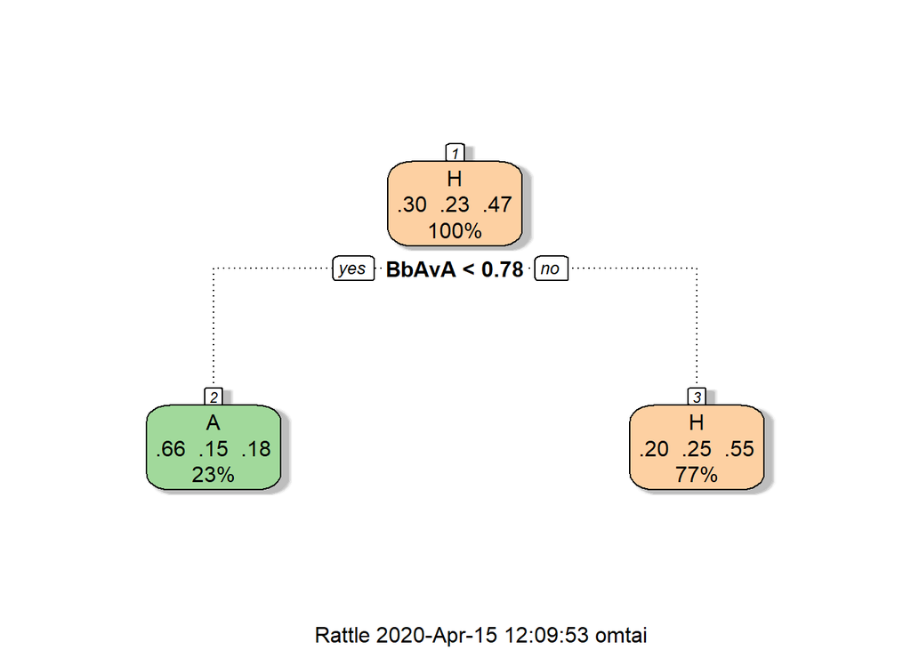

```r
#Classification Tree
EPLTree <- rpart(FTR~. , data= ModelData, method = "class")
fancyRpartPlot(EPLTree)
```

```r
printcp(EPLTree)
```

```
##
## Classification tree:
## rpart(formula = FTR ~ ., data = ModelData, method = "class")
##
## Variables actually used in tree construction:
## [1] BbAvA
##
## Root node error: 684/1290 = 0.53023
##
## n= 1290
##
##        CP nsplit rel error  xerror     xstd
## 1 0.20322      0   1.00000 1.00000 0.026207
## 2 0.01000      1   0.79678 0.80994 0.025992
```

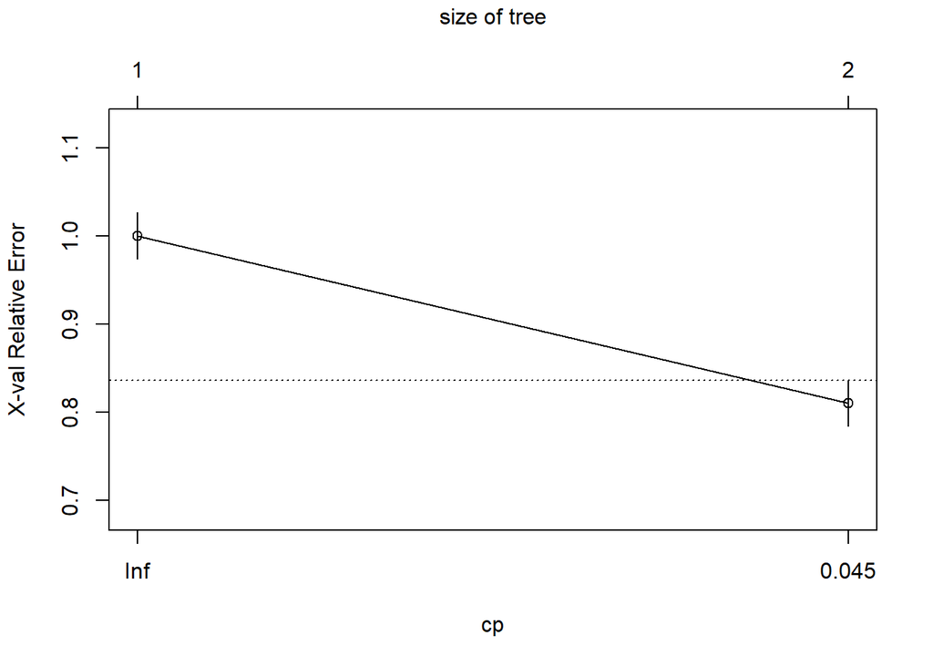

```r
plotcp(EPLTree)
```

```r
#Predicion - All data
predictFTR = predict(EPLTree, type = "class")
table(predictFTR, ModelData$FTR)
```

```
##
## predictFTR   A   D   H
##          A 193  45  54
##          D   0   0   0
##          H 199 247 552
```

```r
#Collect Train and Test Data
library(caTools)
set.seed(3000)
spl <- sample.split(ModelData$FTR, SplitRatio = 0.7)
Train <- subset(ModelData, spl == TRUE)
Test <- subset(ModelData, spl == FALSE)

#Cross Validation
numFolds <- trainControl(method="cv", number=5)
cpGrid <- expand.grid(.cp=seq(0.0001,0.05,0.0001))#cp paramaeters to test as numbers from 0.0005 to 0.05, in increments of 0.01.
train(FTR~YellowrDiff+FoulsrDiff+CornersrDiff+STrDiff+BbAvH, data = Train, method="rpart", trControl=numFolds, tuneGrid = cpGrid) #cp = 0.0155
```

```
## CART
##
## 902 samples
##   5 predictor
##   3 classes: 'A', 'D', 'H'
##
## No pre-processing
## Resampling: Cross-Validated (5 fold)
## Summary of sample sizes: 721, 723, 721, 722, 721
## Resampling results across tuning parameters:
##
##   cp      Accuracy   Kappa
##   0.0001  0.5244266  0.2386084
##   0.0002  0.5244266  0.2386084
##   0.0003  0.5244266  0.2386084
##   0.0004  0.5244266  0.2386084
##   0.0005  0.5244266  0.2386084
##   0.0006  0.5244266  0.2386084
##   0.0007  0.5244266  0.2386084
##   0.0008  0.5244266  0.2386084
##   0.0009  0.5277415  0.2404404
##   0.0010  0.5277415  0.2404404
##   0.0011  0.5255316  0.2355376
##   0.0012  0.5255316  0.2355376
##   0.0013  0.5255316  0.2355376
##   0.0014  0.5277539  0.2370094
##   0.0015  0.5277539  0.2370094
##   0.0016  0.5299638  0.2411744
##   0.0017  0.5299638  0.2411744
##   0.0018  0.5210129  0.2276520
##   0.0019  0.5210129  0.2276520
##   0.0020  0.5210129  0.2276520
##   0.0021  0.5276428  0.2349127
##   0.0022  0.5276428  0.2349127
##   0.0023  0.5276428  0.2349127
##   0.0024  0.5276428  0.2349127
##   0.0025  0.5276428  0.2349127
##   0.0026  0.5276428  0.2349127
##   0.0027  0.5453902  0.2545535
##   0.0028  0.5453902  0.2545535
```

[output cut: 460 more lines]

```
##   0.0489  0.5676005  0.2704983
##   0.0490  0.5676005  0.2704983
##   0.0491  0.5676005  0.2704983
##   0.0492  0.5676005  0.2704983
##   0.0493  0.5676005  0.2704983
##   0.0494  0.5676005  0.2704983
##   0.0495  0.5676005  0.2704983
##   0.0496  0.5676005  0.2704983
##   0.0497  0.5676005  0.2704983
##   0.0498  0.5676005  0.2704983
##   0.0499  0.5676005  0.2704983
##   0.0500  0.5676005  0.2704983
##
## Accuracy was used to select the optimal model using the largest value.
## The final value used for the model was cp = 0.05.
```

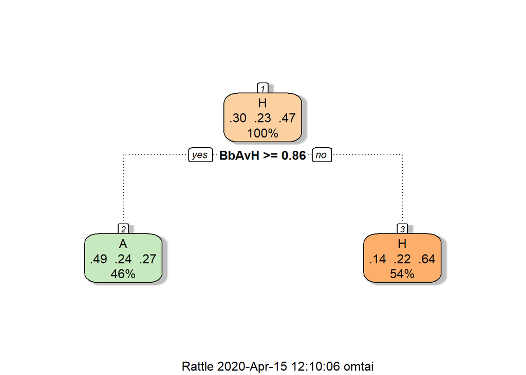

```r
#Classification Tree - With Validation Set
EPLTree <- rpart(FTR~YellowrDiff+FoulsrDiff+CornersrDiff+STrDiff+BbAvH, data= Train, method = "class",  cp = 0.0088)
fancyRpartPlot(EPLTree)
```

```r
#Predicion - Test data
predictFTR = predict(EPLTree, type = "class", newdata = Test)
#fourfoldplot (table(predictFTR, Test$FTR))
```

# Random Forest

```r
EPLForest = randomForest(FTR~., data= Train,ntree = 200, nodesize = 38 )
predictFTRForest = predict(EPLForest, newdata = Test)
table(predictFTRForest, Test$FTR)
```

```
##
## predictFTRForest   A   D   H
##                A  67  21  27
##                D   1   4   8
##                H  50  63 147
```

```r
EPLForest = randomForest(FTR~YellowrDiff+FoulsrDiff+CornersrDiff+STrDiff+BbAvH+spi2+spi1+BbAvD+BbAvA+adj_scorerDiff+FTGrDiff+proj_scoreDiff, data= Train,ntree = 200, nodesize = 38)
predictFTRForest = predict(EPLForest, newdata = Test)
table(predictFTRForest, Test$FTR)
```

```
##
## predictFTRForest   A   D   H
##                A  64  19  27
##                D   5   8  12
##                H  49  61 143
```

```r
# Tune Parameters
```

# Multinomial Logistic Regression

```r
glmModel = multinom(FTR~., data= Train)
summary(glmModel)
```

```
## Call:
## multinom(formula = FTR ~ ., data = Train)
##
## Coefficients:
##   (Intercept)      BbAvH     BbAvD      BbAvA         spi1         spi2
## D    2.826982 -0.6885345 -2.174362  0.2836947 -0.012850179 -0.008815194
## H    2.045380 -2.0775750  0.292970 -0.3495398 -0.001307318 -0.010718757
##      prob1    prob2   probtie   FTGrDiff      STrDiff   FoulsrDiff CornersrDiff
## D 5.489388 1.428159 -4.090937 0.09551953  0.111668056 -0.019111000   0.08114819
## H 3.486282 1.605988 -3.001769 0.12303443 -0.006824029 -0.006495145   0.04634460
##   YellowrDiff    xgrDiff   nsxgrDiff adj_scorerDiff      spiDiff proj_scoreDiff
## D  0.06980853 -0.2886501  0.26483666   -0.004294525 -0.004034985     -0.6159763
## H -0.01430270  0.1649130 -0.09797801   -0.040221677  0.009411439     -0.4549498
##    attackDiff InefficiencyDiff
## D -0.02810795      -0.12362748
## H  0.02671334      -0.09632108
##
## Std. Errors:
##   (Intercept)    BbAvH    BbAvD    BbAvA       spi1       spi2    prob1
## D    1.281107 1.224829 1.525666 1.162723 0.01271965 0.01421684 3.375957
## H    1.146318 1.115318 1.344430 1.052146 0.01143459 0.01240736 3.047742
##      prob2  probtie  FTGrDiff    STrDiff FoulsrDiff CornersrDiff YellowrDiff
## D 3.067320 2.534642 0.1965217 0.08504517 0.04696710   0.06182487   0.1325179
## H 2.701412 2.246865 0.1671533 0.07592766 0.04268287   0.05572407   0.1206410
##     xgrDiff nsxgrDiff adj_scorerDiff    spiDiff proj_scoreDiff attackDiff
## D 0.2952423 0.2519246      0.2646483 0.02276131      0.9689809 0.07299342
## H 0.2630805 0.2237914      0.2291803 0.01997184      0.8636506 0.06475023
##   InefficiencyDiff
## D        0.1476052
## H        0.1230809
##
## Residual Deviance: 1632.751
## AIC: 1704.751
```

```r
predictGlm =predict(glmModel,Test, "class")
predictGlmProbs =predict(glmModel,Test, "probs")
table(predictGlm, Test$FTR)
```

```
##
## predictGlm   A   D   H
##          A  60  18  25
##          D   3   6  11
##          H  55  64 146
```

```r
predictionCompare = as.data.table(cbind(predictGlm, predictGlmProbs, Test$FTR))
```

# Linear Discriminant Analysis and Quadratic Discriminat Analysis

```r
#Log transform BbAvH for lda to normalize
ldaTrain = copy(Train)
ldaTrain[,BbAvH:=log(BbAvH)]
ldaTrain[,BbAvD:=log(BbAvD)]

ldaTest = copy(Test)
ldaTest[,BbAvH:=log(BbAvH)]
ldaTest[,BbAvD:=log(BbAvD)]
ldaData = rbind(ldaTest,ldaTrain)

ldaModel = lda(FTR~BbAvH+BbAvD+STrDiff+ xgrDiff+ nsxgrDiff+CornersrDiff, data = ldaData, CV=TRUE)
#ldaPred = predict(ldaModel, newdata = ldaTest)
table(ldaModel$class, ldaData$FTR)
```

```
##
##       A   D   H
##   A 205  56  73
##   D   3   2  10
##   H 184 234 523
```

```r
qdaModel = qda(FTR~BbAvH+BbAvD+STrDiff+ xgrDiff+ nsxgrDiff+CornersrDiff, data = ldaTrain)
qdaPred = predict(qdaModel, newdata = ldaTest)
table(qdaPred$class, ldaTest$FTR)
```

```
##
##       A   D   H
##   A  53   9  17
##   D  18  12  27
##   H  47  67 138
```

#Naive Bayes Classifier

```r
naiveModel = naiveBayes(FTR~., data = ldaTrain)
naivePred = predict(naiveModel, ldaTest, "class")
table(naivePred, ldaTest$FTR)
```

```
##
## naivePred  A  D  H
##         A 66 23 33
##         D 42 40 79
##         H 10 25 70
```